# ATAC-seq 数据分析标准报告

2025-10-15

万乘经纬基因科技（北京）有限公司 监制2024年05月

# **项目信息**

- 项目编号：SO.20250627001–1
- 项目日期：2025-10-15

# **1 前言概述**

## **1.1 背景简介**

染色质是指间期细胞核内由DNA、组蛋白、非组蛋白及少量RNA组成 的线性复合结构，其基本结构单位是核小体。高度折叠的染色质结构在复制和 转录时需要暴露DNA序列，这段暴露的区域就是染色质开放区，可以与转录 因子或其他调控元件结合，因此这段区域与转录调控是密切相关的。这种致密 的核小体结构被破坏后，顺式调控元件（eg.启动子、增强子）和反式作用因 子（eg.绝缘子、沉默子）可以接近的特性，被称之为染色质的可及性。染色 质可及性与特异的顺式调控元件、反式作用因子密切相关，异常的基因表达或 者染色质调控因子的改变都将对细胞的命运产生深远的影响。 染色质开放可及性分析（AssayforTargetingAccessible-Chromatinwith high-throughoutsequencing,ATAC-seq）是指通过改造后的Tn5转座酶鉴定开 放染色质区域来研究基因组物理结构的测序技术，该技术是2013年由斯坦福 大学WilliamJ.Greenleaf和HowardY.Chang实验室开发的（Buenrostro,Giresi, Zaba,Chang,&Greenleaf,2013）。通过使用该技术对某种特定条件下的开放染 色质区域进行捕获，进而获得调控序列的信息，在表观遗传学领域具有广阔的 发展前景。 相比传统方法，ATAC-seq的结果具有很强的一致性，同时也和基于组蛋 白修饰Marker的ChIP-seq有较高的吻合程度。另外，ATAC-seq的重复性，比MNase-seq和DNase-seq的更强，操作起来也更加简单，细胞或组织的需求 量较少，出来的信号更加漂亮。目前，ATAC-seq除了可以绘制全基因组染色 质可及性图谱、预测转录因子结合位点、测定核小体的位置，还可被用于测定 单个细胞中染色质的可及性，从而揭示细胞群体内的异质性。ATAC-seq已经 成为目前研究染色质开放性首选的技术方法。

# **2 技术流程**

## **2.1 实验流程**

ATAC-seq的核心实验流程包括细胞核提取纯化、Tn5酶切、DNA回收纯 化扩增、分选目的片段建库、测序，其中每一环节都会对数据质量产生影响， 从而直接影响后续生信分析的结果。万乘基因建立了完善的生产步骤，严格把 控样本提核、酶切、建库、测序每一环节，从源头确保高质量数据的产出。技 术原理如下图所示：

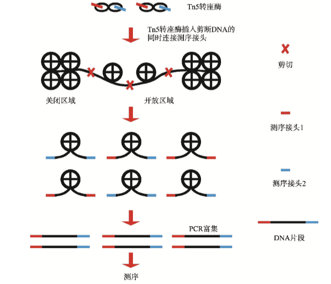

整体实验的流程如下图所示：

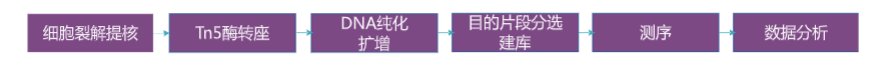

### 2.1.1 细胞裂解提核

将用提前预冷的PBS清洗过的冻存组织置于冰上解冻剪碎，并加入适量组织裂解液，研磨成匀浆，过滤后沉淀细胞核。**通常要求：细胞核数目约60,000。**

### 2.1.2 Tn5酶转座

将上述得到的细胞核沉淀与ATAC-seq裂解液重悬混匀，加入洗涤液后沉 淀。往沉淀中加入反应液，再次重悬混匀，让细胞核与Tn5酶充分反应。

### 2.1.3 DNA纯化、预扩增

使用DNA纯化试剂盒将上述产物进行纯化，并取出少量纯化产物进行预 扩增以确定PCR循环数

### 2.1.4 文库构建

预扩增条带正确后进行正式扩增，确定产量和带型后，纯化构建文库。

### 2.1.5 测序

通常使用IlluminaNovaSeq6000测序平台，采用PE150测序模式，万乘 基因推荐测序量为6G，可以根据实际需求进行加测。

## **2.2 生信分析流程**

万乘基因首先利用FastQC软件对原始数据进行质量评估；再使用Bowtie2 软件将原始数据比对到参考基因组；然后用MACS2分别对每例样本进行峰挖掘 （PeakCalling），之后对peaks区域进行基因组位置注释、Motif分析，并对靶 基因进行GO和KEGG富集分析；如果项目具有多组实验样本，可挖掘各组样 本间具有差异的Peaks进行特异性分析等。万乘基因将根据您的研究需要，评估 后提供定制化分析内容。

[figure not shown]

## **2.3 引用说明**

万乘基因预祝您的研究成果发表见刊，材料方法（METHODS）中数据分析部分引用时，请注明公司全称”10K Genomics”，参考如下：

**1、“**ATAC-seq data analyses were performed by 10K Genomics, Shanghai, China.*“**

**2、“*10K Genomics, Shanghai, China, performed ATAC-seq data analyses.*”**

# **3 数据质控**

## **3.1 原始数据预处理**

测序产生的原始数据（raw data）需要进行预处理，我司使用cutadapt过滤掉不合格的序列后得到有效数据（clean data）

### **FastQC 质控**

我们使用fastqc软件对测序数据进行质控，输出的主要结果如图3-1。横坐标代表序列的碱基位置，纵坐标代表该碱基位置的质量分数分布，分数越高（绿色区域）表示测序质量越好，可靠性更高。详见附件”\2-fastqc_out“。

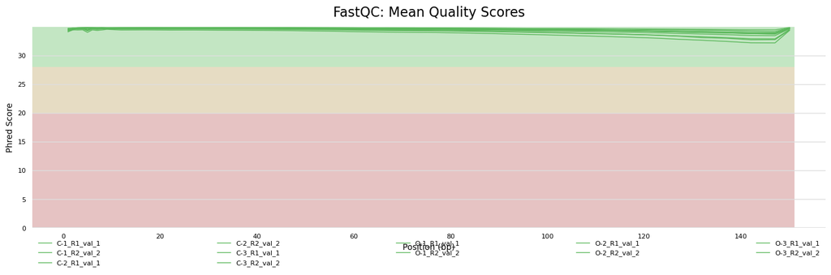

Quality scores Per base sequence quality

# **4 序列比对质控**

## **4.1 参考序列比对（Reads Mapping）统计**

测得Reads与参考序列进行比对（Reads Mapping），可以对测序数据的比对情况进行详细的统计，以便对参考序列选取以及测序数据比对结果是否合理进行整体的评价。Reads mapping主要检验唯一比对reads数（unique mapped reads），**唯一比对率越高代表数据质量越好**。成功比对上的reads会使用Picard软件进行去重，去除PCR扩增带来的重复reads。

比对去重结果统计结果如下：

参考序列比对结果统计表

| Sample | AllReads | MappedReads | UniqueMappedReads | UniqueMapRate | AlignmentRate | DuplicateRate | UniqFragNum | PeakNumber | FRiP | TSS.score |
| --- | --- | --- | --- | --- | --- | --- | --- | --- | --- | --- |
| C-1 | 52222046 | 44482738 | 35751795 | 68.46% | 85.18% | 72.5547% | 12199334 | 2197 | 35.1369% | 1.821943 |
| C-2 | 27232648 | 22692965 | 18360418 | 67.42% | 83.33% | 65.0967% | 7915770 | 2362 | 31.8830% | 1.857071 |
| C-3 | 33208189 | 27476455 | 22092388 | 66.53% | 82.74% | 46.0805% | 14802872 | 2339 | 34.7266% | 1.808792 |
| O-1 | 29488601 | 24248476 | 16236438 | 55.06% | 82.23% | 81.0105% | 4600654 | 1256 | 38.8699% | 2.169781 |
| O-2 | 28731538 | 26973167 | 21374269 | 74.39% | 93.88% | 88.0872% | 3210234 | 1631 | 31.8899% | 1.907322 |
| O-3 | 21502422 | 17784653 | 13913877 | 64.71% | 82.71% | 69.3719% | 5441409 | 2096 | 30.3439% | 1.885483 |

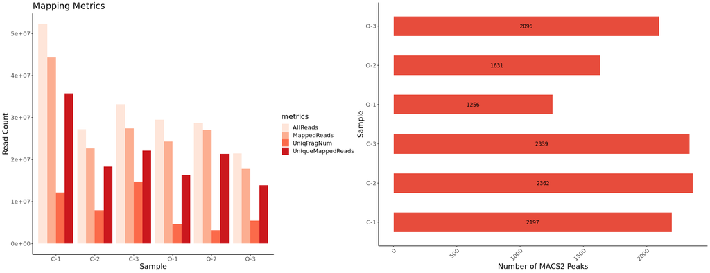

**注释**

- **All Reads：**原始数据处理后，参考序列比对分析中输入的reada数目；
- **Mapped reads：**成功比对至参考基因组的reads数；
- **UniqueMappedReads：**成功比对至参考基因组，且只比对成功一次（唯一）的reads数；
- **UniqueMappingRate：**唯一比对至参考基因组的reads的占比；
- **AlignmentRate：**所有（包括非唯一）成功比对至参考基因组的reads数占比；
- **UniqueFragmentNumber ：**去重后的reads数；
- **Peak number：**去重后检测到的可及位点数（macs2参数：q value = 0.01）
- 详细附件”\Mapping”

## **4.2 插入片段统计**

插入片段长度是评估实验好坏的指标，统计出的插入片段长度应该符合实验预期的长度

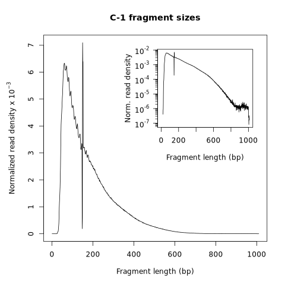

[interactive chart not shown]

**插入片段长度可视化图**

**注释**

- 每200bp会存在一个峰，这个周期性波动反应的是核小体的个数。在ATAC_seq的数据分析中，会对插入片段长度分布进行可视化，观察其是否符合这样的周期性规律，一定程度可以反映文库构建的质量。

## **4.3 IGV可视化**

借助IGV（Integrative Genomics Viewer）或者UCSC Genome Browser等可视化工具，加载\4-bw_out文件夹下的*.bw和narrowpeak文件，可直观查看Peaks在基因组的富集情况。软件下载和使用说明详见：[IGV（Integrative Genomics Viewer）](http://www.broadinstitute.org/software/igv/)

# **5 Peak在功能元件的分布**

全基因组功能性区域可以分为：启动子区（Promoter）、转录起始位置（transcription start site，TSS）、 5’端非翻译区域（5’ untranslated regions，5’ UTR）、3’端非翻译区域（3’ untranslated regions，3’ UTR）、编码外显子区（Coding Exon）、内含子区（Intron）、基因间区（Intergenic）等区域。Peak分布示意见下图：

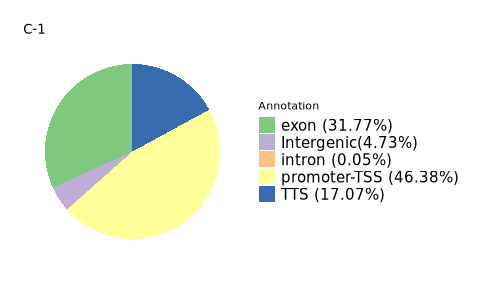

[interactive chart not shown]

**Peak分布图**

**注释**

- 右侧图注表示注释情况，括号内的比例表示分布在该区域的Peak占总Peak的比例。 **详见附件：“\Annotation”**

# **6 Reads在基因附近的分布**

分析reads分布情况可以直观解析数据特性。根据不同研究背景的需要，在提供关注的某一组基因后，可以展示reads在基因上的分布情况热图（heatmap）。此分析可以用于展现同一样本的reads在不同基因中的分布情况，也可用于展现不同样本的reads在同一基因中的分布情况。结果示意如下：

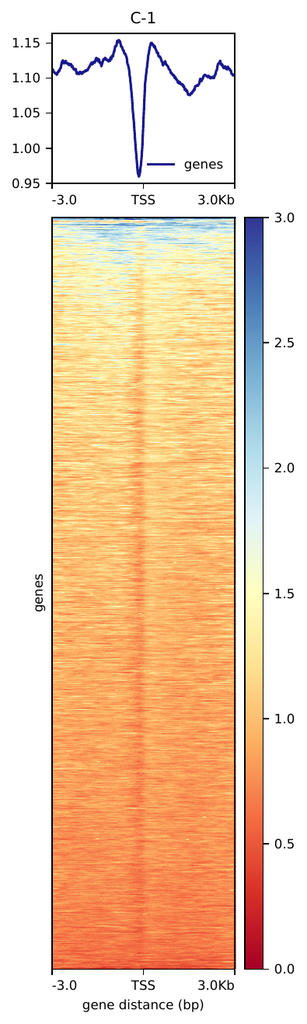

[interactive chart not shown]

**Reads在基因附近的分布特征热图**

**注释**

- 每一行代表一个基因。

**详见附件：“\6-plots”**

# **7 Motif分析**

Motif是指与某些蛋白高亲和度的特定碱基序列。万乘基因使用HOMER软件对Peaks的Motif进行分析，可以预测染色质开放区域结合的潜在转录因子，从而为后续课题研究思路提供借鉴。 具体结果参见附件：“\motif_out

# **8 Diffbind差异分析**

## 8.1样本分析

主成分分析算法是最常用的线性降维方法，其目标是通过某种线性投影， 将高维的数据映射到低维的空间中，使用越少的数据维度，则越多的保留原数 据的特性。样本点越接近，则其Peak模式越类似。

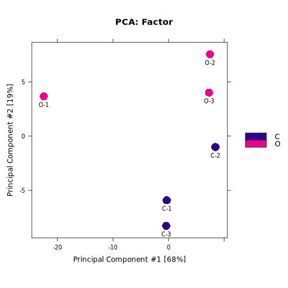

**注释**

- 横纵轴分别代表PCA的第一、第二主成分，每个点代表每个样本，点越近的则表示样本Peak calling情况越类似。 **详见附件：“\Diffbind_out”**

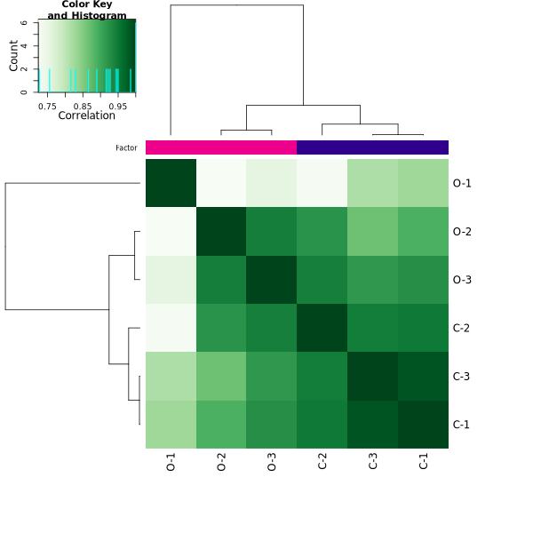

**注释**

- 横纵均代表样本情况，颜色深浅则表示样本相关性大小。 **详见附件：“\Diffbind_out”**

## 8.2差异分析

在ATAC-seq同时做几组样本时，为寻找不同组别间的差异（落在Peak 区间内的reads数量不同而造成的），得到某种状态下特异性结合位点，从而 进一步找到该特异性结合的Motif、靶基因，推测表观遗传是否在某一特定状 态（发育过程、疾病进展）中起到一定作用，通常会将不同组别的Peak进行 比较。

O_vs_C

|  | seqnames | start | end | width | strand | Conc | Conc_O | Conc_C | Fold | p.value | FDR | peak | SYMBOL | annotation |
| --- | --- | --- | --- | --- | --- | --- | --- | --- | --- | --- | --- | --- | --- | --- |
| peak_431 | CP015055.1 | 359331 | 359731 | 401 | * | 8.673128 | 8.184461 | 9.037496 | -0.7720522 | 0e+00 | 0.00e+00 | peak_431 |  | Intergenic |
| peak_38 | CP015054.1 | 244470 | 244870 | 401 | * | 9.220821 | 8.675232 | 9.615762 | -0.8289529 | 0e+00 | 0.00e+00 | peak_38 | gnl\|FIM1\|rna125 | promoter-TSS |
| peak_672 | CP015055.1 | 1576611 | 1577011 | 401 | * | 9.214051 | 8.822562 | 9.521664 | -0.6331611 | 0e+00 | 7.30e-06 | peak_672 | gnl\|FIM1\|rna1651 | promoter-TSS |
| peak_101 | CP015054.1 | 603806 | 604206 | 401 | * | 8.862928 | 8.383076 | 9.222392 | -0.7161201 | 1e-07 | 4.03e-05 | peak_101 | gnl\|FIM1\|rna302 | promoter-TSS |
| peak_2176 | CP015061.1 | 904826 | 905226 | 401 | * | 8.497573 | 7.933855 | 8.901870 | -0.7803380 | 1e-07 | 5.49e-05 | peak_2176 | gnl\|FIM1\|rna4797 | promoter-TSS |

完整差异Peaks表格详见附件：“\Diffbind_out”

**差异peak-火山图**

差异peak火山图，反映了两组样品间peak富集差异程度

- 筛选参数：P value< 0.05且|log2FC|>0

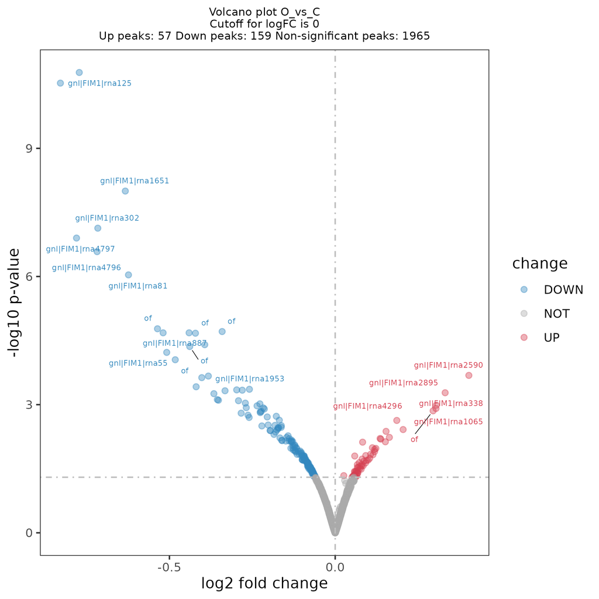

[interactive chart not shown]

# 使用软件列表

**ATAC-seq数据分析使用软件列表**

| **Software** | **Version** | **Main function** |
| --- | --- | --- |
| **Fastqc** | 0.11.8 | Quality control |
| **Cutadapt** | 1.10 | Adapter Remove |
| **Bowtie2** | 2.2.9 | Alignment |
| **Samtools** | 1.9 | Sort reads |
| **MACS2** | 2.1.0 | Peak Calling |
| **Qualimap** | 2.2.2 | Quality control of the alignment |
| **Deeptool** | 3.3.0 | Visualization |
| **DiffBind** | 3.8.4 | Differential peaks Analysis |
| **ClusterProfiler** | 4.6.2 | Functional Enrichment |
| **R** | 4.2 | Statistical analysis |
| **Homer** | 4.1.5 | Motif Analysis |

# 参考文献

[1] Buenrostro,J.D.,Giresi,P.G.,Zaba,L.C.,Chang,H.Y.,&Greenleaf,W.J.(2013).Transposition of native chromatin for fast and sensitive epigenomic profiling of open chromatin ,DNA-binding proteins and nucleosome position. NatMethods,10(12),1213-1218.doi:10.1038/nmeth.2688

[2] Andrews, S. (2010) FastQC: A Quality Control Tool for High Throughput Sequence Data.(https://www.bioinformatics.babraham.ac.uk/projects/fastqc/)

[3] Langmead, B., Salzberg, S. Fast gapped-read alignment with Bowtie 2. Nat Methods 9, 357–359 (2012). https://doi.org/10.1038/nmeth.1923

[4] Zhang, Y., Liu, T., Meyer, C. A., Eeckhoute, J., Johnson, D. S., Bernstein, B. E., … & Liu, X. S. (2008). Model-based analysis of ChIP-Seq (MACS). Genome Biology, 9(9), R137. https://doi.org/10.1186/gb-2008-9-9-r137

[5] Ramirez, F., Ryan, D. P., Gruning, B. A., Bhardwaj, V., Kilpert, F., Manke, T., … & Dundar, F. (2016). deepTools: a flexible platform for exploring deep-sequencing data. Nucleic Acids Research, 44(W1), W160-W165. https://doi.org/10.1093/nar/gkw257

[6] Stark R and Brown G (2011). DiffBind: differential binding analysis of ChIP-Seq peak data. Bioconductor http://bioconductor.org/packages/release/bioc/vignettes/DiffBind/inst/doc/DiffBind.pdf

[7] Heinz S, Benner C, Spann N, Bertolino E et al. Simple Combinations of Lineage-Determining Transcription Factors Prime cis-Regulatory Elements Required for Macrophage and B Cell Identities. Mol Cell 2010 May 28;38(4):576-589. PMID: 20513432

# 附件目录结构

**点击查看目录结构**

Mapping/

Alignment_Stats.csv:每个样品比对到参考基因组参数统计

Stats.pdf/png: 统计参数图

4-bw_out/

*.peak.bw:BigWig文件，可用于igv可视化reads覆盖基因组的情况

*.peak.narrowPeak:MACS2 Peakcalling 结果，igv可视化peak位置

6-plots/

*.peak.TSS_Profile-3kb.png.pdf:Reads在TSS上下游3kb的富集情况折线图

*.peak.TSS_Heatmap-3kb.png.pdf:Reads在TSS上下游3kb的富集情况热图

7-motif_out/

*.html:homer预测的默认数据库内已知motif结果

*.html:homer预测的denovo motif富集结果

annotation_out/

*.dedup_peaks_annotation_prop.csv: peaks功能元件注释占比统计

*.dedup_peaks_annotation.xls:peaks功能元件注释详细结果

ATAC-seq-report.html:本标准分析报告